# Year 2 envRS and PRS for longitudinal outcomes

Year 2 envRS were trained on parent-reported CBCL subscales for internalizing (intRS) and depression (depRS) symptoms. Here I am testing associations between year 2 envRS and longitudinal outcomes, plus the combination of envRS and MDD3 PRS.

PRS data based on MDD3 GWAS (from Poppy) were available for 4161 participants. At year 3, CBCL data were available for 8306 participants. A total of 2332 participants have year 3 CBCL data, PRS and year 2 envRS.  
Model comparisons are run for:  
m1 = cbcl ~ envRS  
m2 = cbcl ~ envRS + PRS  
m3 = cbcl ~ envRS*PRS

# Y3 CBCL Depression

## depRS + PRS

### Performance metrics

| Name | Model | AIC (weights) | AICc (weights) | BIC (weights) | R2 | R2 (adj.) | RMSE | Sigma |
| --- | --- | --- | --- | --- | --- | --- | --- | --- |
| m1 | lm | 6075.8 (0.437) | 6075.8 (0.438) | 6093.0 (0.950) | 0.207 | 0.207 | 0.890 | 0.890 |
| m2 | lm | 6075.9 (0.398) | 6076.0 (0.397) | 6099.0 (0.049) | 0.208 | 0.207 | 0.890 | 0.890 |
| m3 | lm | 6077.7 (0.165) | 6077.7 (0.165) | 6106.5 (0.001) | 0.208 | 0.207 | 0.890 | 0.890 |

### Model comparisons

| Name | Model | BF | df | df_diff | Chi2 | p |
| --- | --- | --- | --- | --- | --- | --- |
| m1 | lm |  | 3 |  |  |  |
| m2 | lm | 0.051 | 4 | 1.000 | 1.811 | 0.178 |
| m3 | lm | 0.023 | 5 | 1.000 | 0.246 | 0.620 |

Models were detected as nested (in terms of fixed parameters) and are compared in sequential order.

### Plot

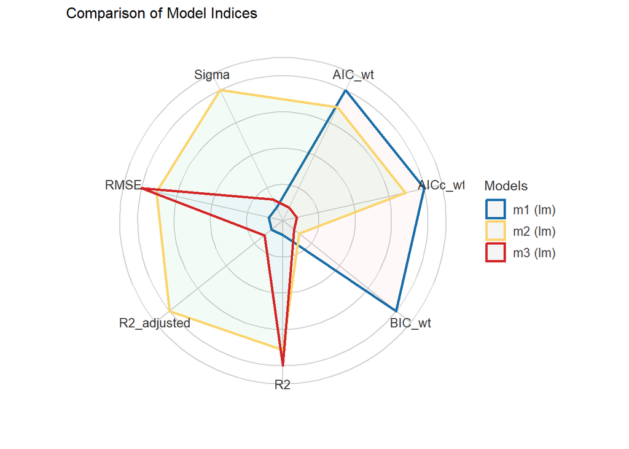

### Estimates

|  | m1 |  |  |  | m2 |  |  |  | m3 |  |  |  |
| --- | --- | --- | --- | --- | --- | --- | --- | --- | --- | --- | --- | --- |
| Predictors | Estimates | std. Error | Statistic | p | Estimates | std. Error | Statistic | p | Estimates | std. Error | Statistic | p |
| (Intercept) | 0.00 (-0.04 – 0.04) | 0.02 | 0.01 | 0.993 | 0.00 (-0.04 – 0.04) | 0.02 | 0.01 | 0.994 | -0.00 (-0.04 – 0.04) | 0.02 | -0.06 | 0.956 |
| depRS y2 | 0.46 (0.42 – 0.49) | 0.02 | 24.68 | **<0.001** | 0.45 (0.42 – 0.49) | 0.02 | 24.31 | **<0.001** | 0.45 (0.41 – 0.49) | 0.02 | 24.21 | **<0.001** |
| PRS |  |  |  |  | 0.03 (-0.01 – 0.06) | 0.02 | 1.35 | 0.179 | 0.03 (-0.01 – 0.06) | 0.02 | 1.35 | 0.178 |
| depRS y2 × PRS |  |  |  |  |  |  |  |  | 0.01 (-0.03 – 0.05) | 0.02 | 0.50 | 0.620 |
| Observations | 2330 |  |  |  | 2330 |  |  |  | 2330 |  |  |  |
| R<sup>2</sup> / R<sup>2</sup> adjusted | 0.207 / 0.207 |  |  |  | 0.208 / 0.207 |  |  |  | 0.208 / 0.207 |  |  |  |

| model | Accuracy | SE | CI | CI_low | CI_high | Method |
| --- | --- | --- | --- | --- | --- | --- |
| m1 | 0.453 | 0.068 | 0.95 | 0.373 | 0.540 | Correlation between observed and predicted |
| m2 | 0.456 | 0.044 | 0.95 | 0.394 | 0.501 | Correlation between observed and predicted |
| m3 | 0.456 | 0.032 | 0.95 | 0.427 | 0.503 | Correlation between observed and predicted |

## envRS combined

Uses larger sample of envRS only data (N = 5383)

### Performance metrics

| Name | Model | AIC (weights) | AICc (weights) | BIC (weights) | R2 | R2 (adj.) | RMSE | Sigma |
| --- | --- | --- | --- | --- | --- | --- | --- | --- |
| dep_mod | lm | 23834.3 (0.026) | 23834.3 (0.026) | 23854.1 (0.939) | 0.205 | 0.205 | 2.215 | 2.215 |
| comb_mod | lm | 23836.3 (0.010) | 23836.3 (0.010) | 23862.6 (0.013) | 0.205 | 0.205 | 2.215 | 2.215 |
| interact | lm | 23827.1 (0.964) | 23827.1 (0.964) | 23860.1 (0.048) | 0.207 | 0.206 | 2.213 | 2.213 |

### Model comparisons

| Name | Model | BF | df | df_diff | Chi2 | p |
| --- | --- | --- | --- | --- | --- | --- |
| dep_mod | lm |  | 3 |  |  |  |
| comb_mod | lm | 0.014 | 4 | 1.000 | 0.074 | 0.786 |
| interact | lm | 3.61 | 5 | 1.000 | 11.159 | < .001 |

Models were detected as nested (in terms of fixed parameters) and are compared in sequential order.

### Plot

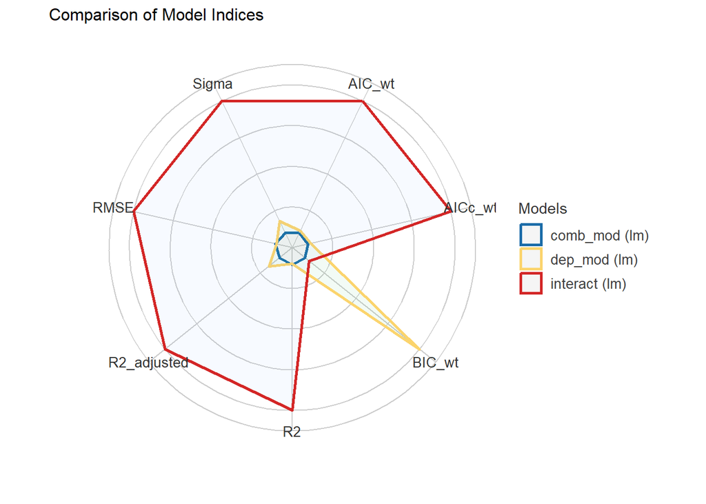

### Estimates

|  | dep_mod |  |  |  | comb_mod |  |  |  | interact |  |  |  |
| --- | --- | --- | --- | --- | --- | --- | --- | --- | --- | --- | --- | --- |
| Predictors | Estimates | std. Error | Statistic | p | Estimates | std. Error | Statistic | p | Estimates | std. Error | Statistic | p |
| (Intercept) | 1.71 (1.65 – 1.77) | 0.03 | 56.66 | **<0.001** | 1.71 (1.65 – 1.77) | 0.03 | 56.65 | **<0.001** | 1.65 (1.57 – 1.72) | 0.04 | 45.69 | **<0.001** |
| depRS y2 | 2.12 (2.01 – 2.23) | 0.06 | 37.27 | **<0.001** | 2.06 (1.63 – 2.49) | 0.22 | 9.42 | **<0.001** | 2.12 (1.69 – 2.55) | 0.22 | 9.68 | **<0.001** |
| intRS y2 |  |  |  |  | 0.06 (-0.38 – 0.51) | 0.23 | 0.27 | 0.786 | -0.12 (-0.58 – 0.34) | 0.23 | -0.51 | 0.612 |
| depRS y2 × intRS y2 |  |  |  |  |  |  |  |  | 0.25 (0.10 – 0.39) | 0.07 | 3.34 | **0.001** |
| Observations | 5381 |  |  |  | 5381 |  |  |  | 5381 |  |  |  |
| R<sup>2</sup> / R<sup>2</sup> adjusted | 0.205 / 0.205 |  |  |  | 0.205 / 0.205 |  |  |  | 0.207 / 0.206 |  |  |  |

| model | Accuracy | SE | CI | CI_low | CI_high | Method |
| --- | --- | --- | --- | --- | --- | --- |
| dep_mod | 0.453 | 0.034 | 0.95 | 0.408 | 0.489 | Correlation between observed and predicted |
| comb_mod | 0.452 | 0.018 | 0.95 | 0.436 | 0.477 | Correlation between observed and predicted |
| interact | 0.453 | 0.036 | 0.95 | 0.414 | 0.502 | Correlation between observed and predicted |

# Y3 CBCL Internalising

## intRS + PRS

### Performance metrics

| Name | Model | AIC (weights) | AICc (weights) | BIC (weights) | R2 | R2 (adj.) | RMSE | Sigma |
| --- | --- | --- | --- | --- | --- | --- | --- | --- |
| m1 | lm | 6110.2 (0.040) | 6110.2 (0.041) | 6127.4 (0.708) | 0.196 | 0.195 | 0.897 | 0.897 |
| m2 | lm | 6106.5 (0.255) | 6106.5 (0.256) | 6129.5 (0.253) | 0.198 | 0.197 | 0.896 | 0.896 |
| m3 | lm | 6104.4 (0.704) | 6104.5 (0.703) | 6133.2 (0.039) | 0.199 | 0.198 | 0.895 | 0.896 |

### Model comparisons

| Name | Model | BF | df | df_diff | Chi2 | p |
| --- | --- | --- | --- | --- | --- | --- |
| m1 | lm |  | 3 |  |  |  |
| m2 | lm | 0.357 | 4 | 1.000 | 5.695 | 0.017 |
| m3 | lm | 0.155 | 5 | 1.000 | 4.030 | 0.045 |

Models were detected as nested (in terms of fixed parameters) and are compared in sequential order.

### Plot

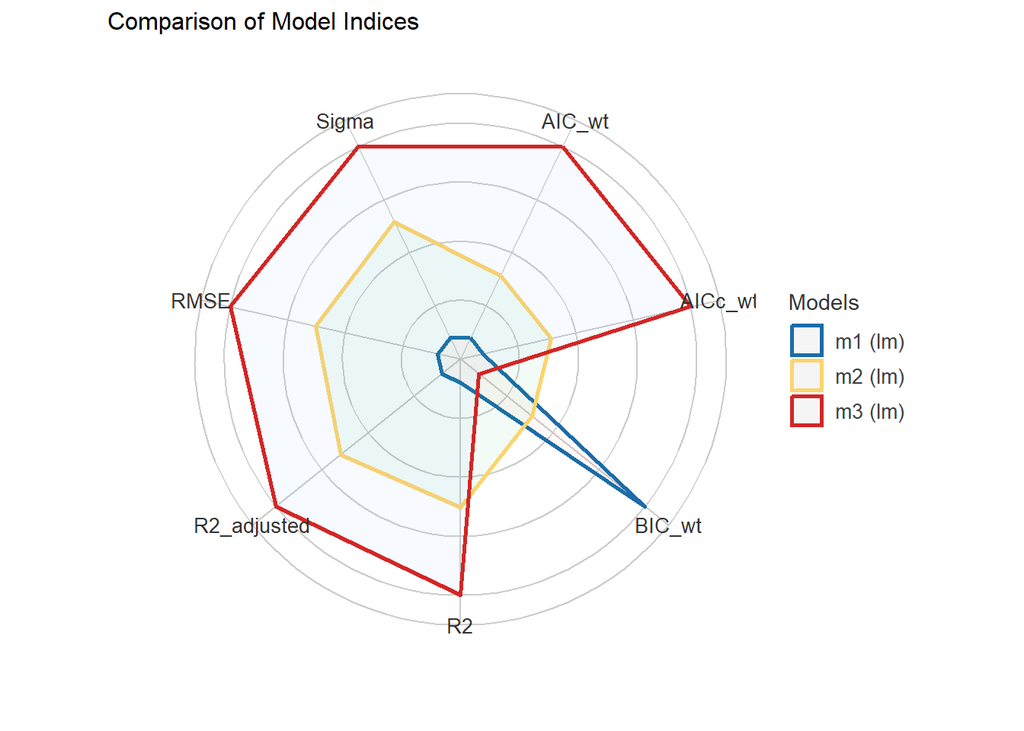

### Estimates

|  | m1 |  |  |  | m2 |  |  |  | m3 |  |  |  |
| --- | --- | --- | --- | --- | --- | --- | --- | --- | --- | --- | --- | --- |
| Predictors | Estimates | std. Error | Statistic | p | Estimates | std. Error | Statistic | p | Estimates | std. Error | Statistic | p |
| (Intercept) | 0.00 (-0.04 – 0.04) | 0.02 | 0.00 | 0.997 | 0.00 (-0.04 – 0.04) | 0.02 | 0.00 | 0.998 | -0.00 (-0.04 – 0.03) | 0.02 | -0.23 | 0.820 |
| intRS y2 | 0.44 (0.41 – 0.48) | 0.02 | 23.79 | **<0.001** | 0.44 (0.40 – 0.47) | 0.02 | 23.38 | **<0.001** | 0.43 (0.40 – 0.47) | 0.02 | 23.11 | **<0.001** |
| PRS |  |  |  |  | 0.04 (0.01 – 0.08) | 0.02 | 2.39 | **0.017** | 0.04 (0.01 – 0.08) | 0.02 | 2.39 | **0.017** |
| intRS y2 × PRS |  |  |  |  |  |  |  |  | 0.04 (0.00 – 0.07) | 0.02 | 2.01 | **0.045** |
| Observations | 2330 |  |  |  | 2330 |  |  |  | 2330 |  |  |  |
| R<sup>2</sup> / R<sup>2</sup> adjusted | 0.196 / 0.195 |  |  |  | 0.198 / 0.197 |  |  |  | 0.199 / 0.198 |  |  |  |

| model | Accuracy | SE | CI | CI_low | CI_high | Method |
| --- | --- | --- | --- | --- | --- | --- |
| m1 | 0.442 | 0.028 | 0.95 | 0.416 | 0.483 | Correlation between observed and predicted |
| m2 | 0.444 | 0.030 | 0.95 | 0.413 | 0.485 | Correlation between observed and predicted |
| m3 | 0.441 | 0.044 | 0.95 | 0.388 | 0.500 | Correlation between observed and predicted |

## envRS combined

Uses larger sample of envRS only data (N = 5383)

### Performance metrics

| Name | Model | AIC (weights) | AICc (weights) | BIC (weights) | R2 | R2 (adj.) | RMSE | Sigma |
| --- | --- | --- | --- | --- | --- | --- | --- | --- |
| int_mod | lm | 32971.2 (0.020) | 32971.2 (0.020) | 32991.0 (0.890) | 0.212 | 0.212 | 5.177 | 5.178 |
| comb_mod | lm | 32970.3 (0.031) | 32970.3 (0.031) | 32996.7 (0.052) | 0.212 | 0.212 | 5.175 | 5.177 |
| interact | lm | 32963.5 (0.949) | 32963.5 (0.949) | 32996.4 (0.058) | 0.214 | 0.213 | 5.171 | 5.173 |

### Model comparisons

| Name | Model | BF | df | df_diff | Chi2 | p |
| --- | --- | --- | --- | --- | --- | --- |
| int_mod | lm |  | 3 |  |  |  |
| comb_mod | lm | 0.058 | 4 | 1.000 | 2.902 | 0.088 |
| interact | lm | 1.12 | 5 | 1.000 | 8.819 | 0.003 |

Models were detected as nested (in terms of fixed parameters) and are compared in sequential order.

### Plot

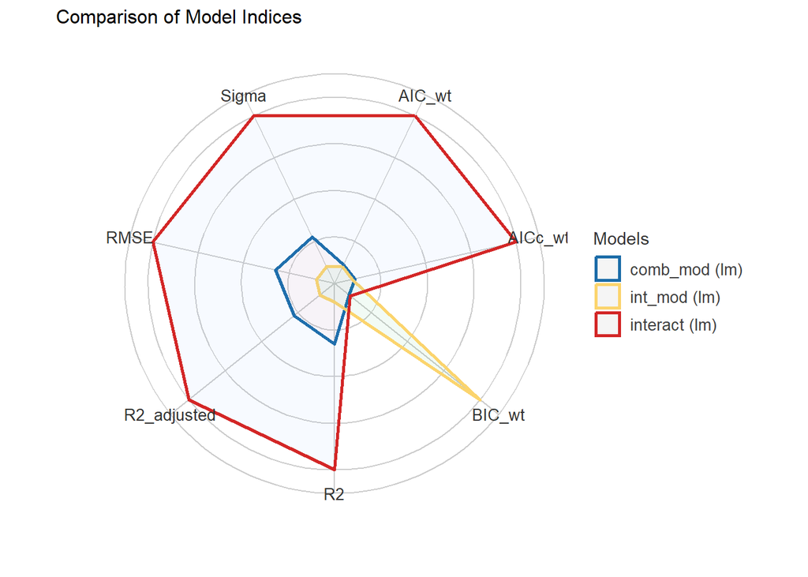

### Estimates

|  | int_mod |  |  |  | comb_mod |  |  |  | interact |  |  |  |
| --- | --- | --- | --- | --- | --- | --- | --- | --- | --- | --- | --- | --- |
| Predictors | Estimates | std. Error | Statistic | p | Estimates | std. Error | Statistic | p | Estimates | std. Error | Statistic | p |
| (Intercept) | 5.21 (5.08 – 5.35) | 0.07 | 73.86 | **<0.001** | 5.21 (5.08 – 5.35) | 0.07 | 73.89 | **<0.001** | 5.08 (4.91 – 5.24) | 0.08 | 60.33 | **<0.001** |
| intRS y2 | 5.25 (4.98 – 5.53) | 0.14 | 38.03 | **<0.001** | 4.38 (3.34 – 5.42) | 0.53 | 8.24 | **<0.001** | 4.01 (2.94 – 5.08) | 0.55 | 7.34 | **<0.001** |
| depRS y2 |  |  |  |  | 0.87 (-0.13 – 1.87) | 0.51 | 1.70 | 0.089 | 1.00 (-0.01 – 2.00) | 0.51 | 1.95 | 0.052 |
| intRS y2 × depRS y2 |  |  |  |  |  |  |  |  | 0.52 (0.18 – 0.86) | 0.17 | 2.97 | **0.003** |
| Observations | 5381 |  |  |  | 5381 |  |  |  | 5381 |  |  |  |
| R<sup>2</sup> / R<sup>2</sup> adjusted | 0.212 / 0.212 |  |  |  | 0.212 / 0.212 |  |  |  | 0.214 / 0.213 |  |  |  |

| model | Accuracy | SE | CI | CI_low | CI_high | Method |
| --- | --- | --- | --- | --- | --- | --- |
| int_mod | 0.459 | 0.023 | 0.95 | 0.433 | 0.484 | Correlation between observed and predicted |
| comb_mod | 0.461 | 0.035 | 0.95 | 0.427 | 0.511 | Correlation between observed and predicted |
| interact | 0.460 | 0.044 | 0.95 | 0.411 | 0.506 | Correlation between observed and predicted |

# Y4 CBCL Depression

At year 4, CBCL data were available for 3807 participants. A total 1260 participants have year 4 CBCL data, PRS and year 2 envRS.  
Model comparisons are run for:  
m1 = cbcl ~ envRS  
m2 = cbcl ~ envRS + PRS  
m3 = cbcl ~ envRS*PRS

## depRS + PRS

### Performance metrics

| Name | Model | AIC (weights) | AICc (weights) | BIC (weights) | R2 | R2 (adj.) | RMSE | Sigma |
| --- | --- | --- | --- | --- | --- | --- | --- | --- |
| m1 | lm | 5894.6 (0.205) | 5894.6 (0.206) | 5910.0 (0.817) | 0.148 | 0.147 | 2.504 | 2.506 |
| m2 | lm | 5892.5 (0.581) | 5892.5 (0.582) | 5913.0 (0.178) | 0.151 | 0.150 | 2.500 | 2.503 |
| m3 | lm | 5894.5 (0.214) | 5894.5 (0.212) | 5920.2 (0.005) | 0.151 | 0.149 | 2.500 | 2.504 |

### Model comparisons

| Name | Model | BF | df | df_diff | Chi2 | p |
| --- | --- | --- | --- | --- | --- | --- |
| m1 | lm |  | 3 |  |  |  |
| m2 | lm | 0.217 | 4 | 1.000 | 4.087 | 0.043 |
| m3 | lm | 0.028 | 5 | 1.000 | 4.441e-04 | 0.983 |

Models were detected as nested (in terms of fixed parameters) and are compared in sequential order.

### Plot

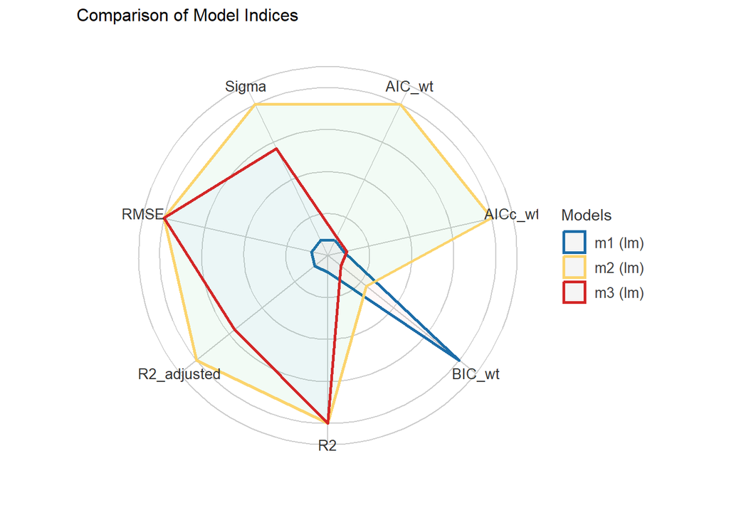

### Estimates

|  | m1 |  |  |  | m2 |  |  |  | m3 |  |  |  |
| --- | --- | --- | --- | --- | --- | --- | --- | --- | --- | --- | --- | --- |
| Predictors | Estimates | std. Error | Statistic | p | Estimates | std. Error | Statistic | p | Estimates | std. Error | Statistic | p |
| (Intercept) | 1.88 (1.74 – 2.02) | 0.07 | 26.65 | **<0.001** | 1.88 (1.74 – 2.02) | 0.07 | 26.67 | **<0.001** | 1.88 (1.74 – 2.02) | 0.07 | 26.32 | **<0.001** |
| depRS y2 | 2.04 (1.77 – 2.31) | 0.14 | 14.79 | **<0.001** | 2.00 (1.72 – 2.27) | 0.14 | 14.32 | **<0.001** | 2.00 (1.72 – 2.27) | 0.14 | 14.27 | **<0.001** |
| PRS |  |  |  |  | 0.14 (0.00 – 0.28) | 0.07 | 2.02 | **0.044** | 0.14 (0.00 – 0.28) | 0.07 | 2.02 | **0.044** |
| depRS y2 × PRS |  |  |  |  |  |  |  |  | 0.00 (-0.27 – 0.28) | 0.14 | 0.02 | 0.983 |
| Observations | 1260 |  |  |  | 1260 |  |  |  | 1260 |  |  |  |
| R<sup>2</sup> / R<sup>2</sup> adjusted | 0.148 / 0.147 |  |  |  | 0.151 / 0.150 |  |  |  | 0.151 / 0.149 |  |  |  |

| model | Accuracy | SE | CI | CI_low | CI_high | Method |
| --- | --- | --- | --- | --- | --- | --- |
| m1 | 0.389 | 0.061 | 0.95 | 0.308 | 0.459 | Correlation between observed and predicted |
| m2 | 0.385 | 0.049 | 0.95 | 0.338 | 0.446 | Correlation between observed and predicted |
| m3 | 0.387 | 0.054 | 0.95 | 0.304 | 0.427 | Correlation between observed and predicted |

## envRS combined

Uses larger sample of envRS only data (N = 2959)

### Performance metrics

| Name | Model | AIC (weights) | AICc (weights) | BIC (weights) | R2 | R2 (adj.) | RMSE | Sigma |
| --- | --- | --- | --- | --- | --- | --- | --- | --- |
| dep_mod | lm | 13795.6 (0.107) | 13795.6 (0.108) | 13813.6 (0.835) | 0.164 | 0.164 | 2.487 | 2.488 |
| comb_mod | lm | 13793.0 (0.398) | 13793.0 (0.399) | 13817.0 (0.155) | 0.165 | 0.165 | 2.485 | 2.487 |
| interact | lm | 13792.6 (0.495) | 13792.6 (0.494) | 13822.5 (0.010) | 0.166 | 0.165 | 2.484 | 2.486 |

### Model comparisons

| Name | Model | BF | df | df_diff | Chi2 | p |
| --- | --- | --- | --- | --- | --- | --- |
| dep_mod | lm |  | 3 |  |  |  |
| comb_mod | lm | 0.186 | 4 | 1.000 | 4.627 | 0.031 |
| interact | lm | 0.062 | 5 | 1.000 | 2.433 | 0.119 |

Models were detected as nested (in terms of fixed parameters) and are compared in sequential order.

### Plot

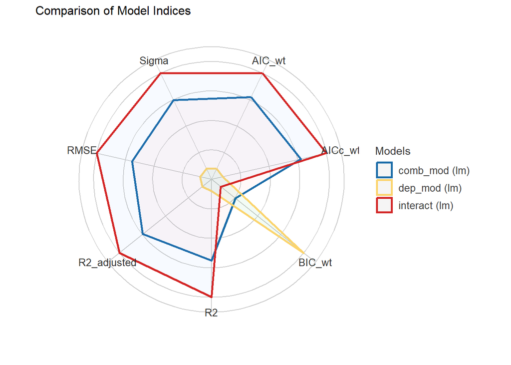

### Estimates

|  | dep_mod |  |  |  | comb_mod |  |  |  | interact |  |  |  |
| --- | --- | --- | --- | --- | --- | --- | --- | --- | --- | --- | --- | --- |
| Predictors | Estimates | std. Error | Statistic | p | Estimates | std. Error | Statistic | p | Estimates | std. Error | Statistic | p |
| (Intercept) | 1.82 (1.73 – 1.91) | 0.05 | 39.73 | **<0.001** | 1.82 (1.73 – 1.91) | 0.05 | 39.75 | **<0.001** | 1.77 (1.66 – 1.88) | 0.06 | 32.00 | **<0.001** |
| depRS y2 | 2.12 (1.94 – 2.29) | 0.09 | 24.09 | **<0.001** | 1.43 (0.79 – 2.08) | 0.33 | 4.35 | **<0.001** | 1.49 (0.84 – 2.14) | 0.33 | 4.50 | **<0.001** |
| intRS y2 |  |  |  |  | 0.74 (0.07 – 1.41) | 0.34 | 2.15 | **0.032** | 0.60 (-0.09 – 1.29) | 0.35 | 1.70 | 0.089 |
| depRS y2 × intRS y2 |  |  |  |  |  |  |  |  | 0.19 (-0.05 – 0.42) | 0.12 | 1.56 | 0.119 |
| Observations | 2959 |  |  |  | 2959 |  |  |  | 2959 |  |  |  |
| R<sup>2</sup> / R<sup>2</sup> adjusted | 0.164 / 0.164 |  |  |  | 0.165 / 0.165 |  |  |  | 0.166 / 0.165 |  |  |  |

| model | Accuracy | SE | CI | CI_low | CI_high | Method |
| --- | --- | --- | --- | --- | --- | --- |
| dep_mod | 0.404 | 0.049 | 0.95 | 0.343 | 0.469 | Correlation between observed and predicted |
| comb_mod | 0.407 | 0.032 | 0.95 | 0.375 | 0.450 | Correlation between observed and predicted |
| interact | 0.405 | 0.018 | 0.95 | 0.388 | 0.430 | Correlation between observed and predicted |

# Y4 CBCL Internalising

## intRS + PRS

### Performance metrics

| Name | Model | AIC (weights) | AICc (weights) | BIC (weights) | R2 | R2 (adj.) | RMSE | Sigma |
| --- | --- | --- | --- | --- | --- | --- | --- | --- |
| m1 | lm | 7828.2 (0.160) | 7828.2 (0.161) | 7843.6 (0.770) | 0.162 | 0.161 | 5.393 | 5.397 |
| m2 | lm | 7825.5 (0.606) | 7825.5 (0.606) | 7846.1 (0.223) | 0.165 | 0.163 | 5.383 | 5.389 |
| m3 | lm | 7827.4 (0.234) | 7827.4 (0.233) | 7853.1 (0.007) | 0.165 | 0.163 | 5.383 | 5.391 |

### Model comparisons

| Name | Model | BF | df | df_diff | Chi2 | p |
| --- | --- | --- | --- | --- | --- | --- |
| m1 | lm |  | 3 |  |  |  |
| m2 | lm | 0.290 | 4 | 1.000 | 4.664 | 0.031 |
| m3 | lm | 0.030 | 5 | 1.000 | 0.101 | 0.751 |

Models were detected as nested (in terms of fixed parameters) and are compared in sequential order.

### Plot

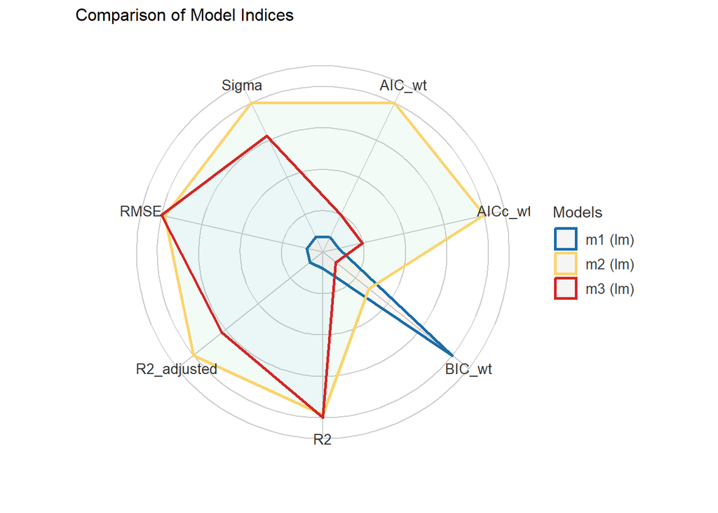

### Estimates

|  | m1 |  |  |  | m2 |  |  |  | m3 |  |  |  |
| --- | --- | --- | --- | --- | --- | --- | --- | --- | --- | --- | --- | --- |
| Predictors | Estimates | std. Error | Statistic | p | Estimates | std. Error | Statistic | p | Estimates | std. Error | Statistic | p |
| (Intercept) | 5.27 (4.97 – 5.57) | 0.15 | 34.68 | **<0.001** | 5.27 (4.97 – 5.57) | 0.15 | 34.72 | **<0.001** | 5.27 (4.97 – 5.57) | 0.15 | 34.35 | **<0.001** |
| intRS y2 | 4.87 (4.26 – 5.49) | 0.31 | 15.58 | **<0.001** | 4.78 (4.17 – 5.40) | 0.32 | 15.17 | **<0.001** | 4.77 (4.15 – 5.40) | 0.32 | 15.06 | **<0.001** |
| PRS |  |  |  |  | 0.33 (0.03 – 0.63) | 0.15 | 2.16 | **0.031** | 0.33 (0.03 – 0.63) | 0.15 | 2.16 | **0.031** |
| intRS y2 × PRS |  |  |  |  |  |  |  |  | 0.10 (-0.52 – 0.72) | 0.32 | 0.32 | 0.752 |
| Observations | 1260 |  |  |  | 1260 |  |  |  | 1260 |  |  |  |
| R<sup>2</sup> / R<sup>2</sup> adjusted | 0.162 / 0.161 |  |  |  | 0.165 / 0.163 |  |  |  | 0.165 / 0.163 |  |  |  |

| model | Accuracy | SE | CI | CI_low | CI_high | Method |
| --- | --- | --- | --- | --- | --- | --- |
| m1 | 0.404 | 0.069 | 0.95 | 0.322 | 0.463 | Correlation between observed and predicted |
| m2 | 0.408 | 0.086 | 0.95 | 0.283 | 0.489 | Correlation between observed and predicted |
| m3 | 0.408 | 0.047 | 0.95 | 0.358 | 0.467 | Correlation between observed and predicted |

## envRS combined

### Performance metrics

| Name | Model | AIC (weights) | AICc (weights) | BIC (weights) | R2 | R2 (adj.) | RMSE | Sigma |
| --- | --- | --- | --- | --- | --- | --- | --- | --- |
| int_mod | lm | 18492.7 (0.574) | 18492.8 (0.575) | 18510.7 (0.974) | 0.182 | 0.181 | 5.501 | 5.503 |
| comb_mod | lm | 18494.0 (0.301) | 18494.1 (0.301) | 18518.0 (0.026) | 0.182 | 0.181 | 5.500 | 5.503 |
| interact | lm | 18495.8 (0.125) | 18495.8 (0.124) | 18525.8 (<.001) | 0.182 | 0.181 | 5.500 | 5.504 |

### Model comparisons

| Name | Model | BF | df | df_diff | Chi2 | p |
| --- | --- | --- | --- | --- | --- | --- |
| int_mod | lm |  | 3 |  |  |  |
| comb_mod | lm | 0.026 | 4 | 1.000 | 0.708 | 0.400 |
| interact | lm | 0.021 | 5 | 1.000 | 0.241 | 0.624 |

Models were detected as nested (in terms of fixed parameters) and are compared in sequential order.

### Plot

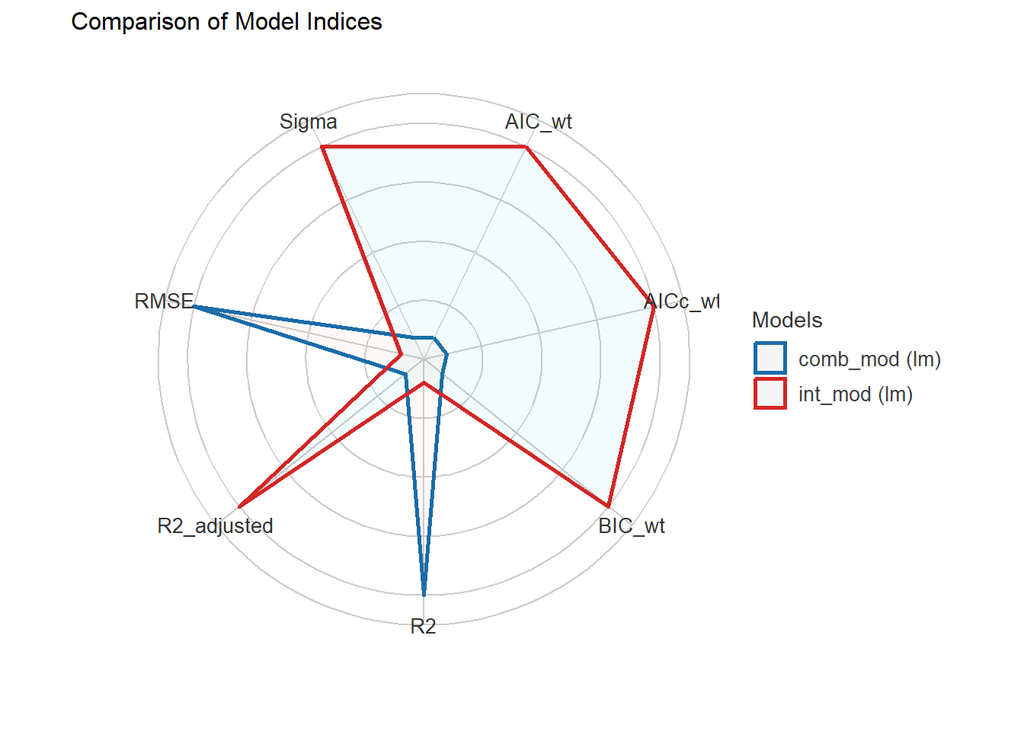

### Estimates

|  | intRS |  |  |  | intRS+depRS |  |  |  | interact |  |  |  |
| --- | --- | --- | --- | --- | --- | --- | --- | --- | --- | --- | --- | --- |
| Predictors | Estimates | std. Error | Statistic | p | Estimates | std. Error | Statistic | p | Estimates | std. Error | Statistic | p |
| (Intercept) | 5.22 (5.03 – 5.42) | 0.10 | 51.62 | **<0.001** | 5.23 (5.03 – 5.42) | 0.10 | 51.62 | **<0.001** | 5.26 (5.02 – 5.50) | 0.12 | 42.96 | **<0.001** |
| intRS y2 | 5.17 (4.78 – 5.57) | 0.20 | 25.63 | **<0.001** | 4.56 (3.07 – 6.04) | 0.76 | 6.02 | **<0.001** | 4.65 (3.12 – 6.18) | 0.78 | 5.96 | **<0.001** |
| depRS y2 |  |  |  |  | 0.61 (-0.82 – 2.04) | 0.73 | 0.84 | 0.400 | 0.57 (-0.86 – 2.01) | 0.73 | 0.78 | 0.434 |
| intRS y2 × depRS y2 |  |  |  |  |  |  |  |  | -0.13 (-0.65 – 0.39) | 0.27 | -0.49 | 0.624 |
| Observations | 2959 |  |  |  | 2959 |  |  |  | 2959 |  |  |  |
| R<sup>2</sup> / R<sup>2</sup> adjusted | 0.182 / 0.181 |  |  |  | 0.182 / 0.181 |  |  |  | 0.182 / 0.181 |  |  |  |

$int_mod # Accuracy of Model Predictions

Accuracy (95% CI): 42.75% [40.76%, 44.39%] Method: Correlation between observed and predicted

$comb_mod # Accuracy of Model Predictions

Accuracy (95% CI): 42.60% [38.39%, 47.38%] Method: Correlation between observed and predicted

$interact # Accuracy of Model Predictions

Accuracy (95% CI): 42.54% [36.70%, 48.07%] Method: Correlation between observed and predicted

# Lifetime MDD diagnosis (youth)

Depression diagnoses (lifetime and current) from *youth-reported* KSADS are available at year 2 (N=5730) and year 2 (N=5732).

# Year 2 (cross-sectional)

For envRS-only analyses, there are 144 lifetime MDD cases, 27 current MDD cases and 278 cases with lifetime diagnoses of a depressive disorder (Major Depressive Disorder, Persistent Depressive Disorder (dysthymia), Depressive Disorder Unspecified).  
Of those with both envRS and PRS at year 2 (N = 2440), there are 45 lifetime MDD cases, 10 current MDD cases and 92 cases with lifetime diagnoses of a depressive disorder (Major Depressive Disorder, Persistent Depressive Disorder (dysthymia), Depressive Disorder Unspecified).  
Current analyses use *just* the lifetime MDD outcome.

## depRS + PRS

### Performance metrics

| Name | Model | AIC (weights) | BIC (weights) | Tjur’s R2 | RMSE | Sigma | Log_loss | Score_log | Score_spherical | AICc (weights) | PCP |
| --- | --- | --- | --- | --- | --- | --- | --- | --- | --- | --- | --- |
| Model 1 | glm | 432.9 (0.610) | 444.5 (0.975) | 0.011 | 0.134 | 1.000 | 0.088 | -0.842 | 0.019 | 432.9 (>.999) | 0.964 |
| Model 2 | glm | 434.4 (0.283) | 451.8 (0.025) | 0.012 | 0.134 | 1.000 | 0.088 | -0.842 | 0.019 | (>.999) |  |
| Model 3 | glm | 436.4 (0.108) | 459.6 (<.001) | 0.011 | 0.134 | 1.000 | 0.088 | -0.842 | 0.019 | (>.999) |  |

### Model comparisons

| Name | Model | BF |
| --- | --- | --- |
| Model 1 | glm |  |
| Model 2 | glm | 0.026 |
| Model 3 | glm | 0.021 |

Models were detected as nested (in terms of fixed parameters) and are compared in sequential order.

### Plot

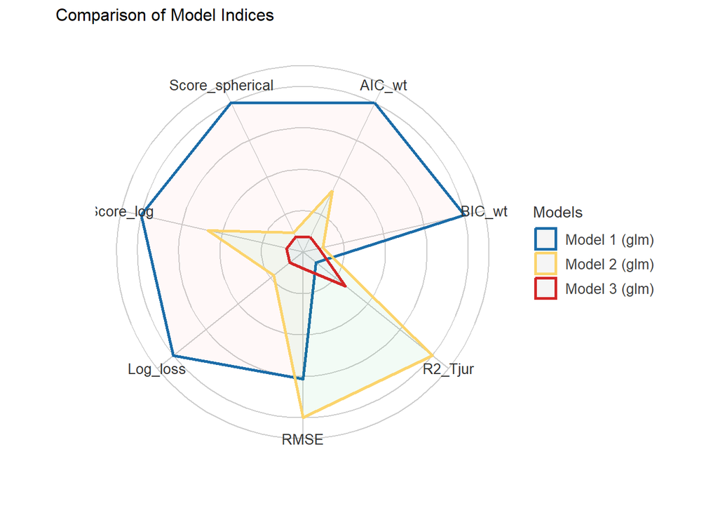

### Estimates

|  | m1 |  |  |  | m2 |  |  |  | m3 |  |  |  |
| --- | --- | --- | --- | --- | --- | --- | --- | --- | --- | --- | --- | --- |
| Predictors | Odds Ratios | std. Error | Statistic | p | Odds Ratios | std. Error | Statistic | p | Odds Ratios | std. Error | Statistic | p |
| (Intercept) | 0.02 (0.01 – 0.02) | 0.00 | -24.21 | **<0.001** | 0.02 (0.01 – 0.02) | 0.00 | -24.16 | **<0.001** | 0.02 (0.01 – 0.02) | 0.00 | -24.08 | **<0.001** |
| depRS y2 | 2.91 (1.85 – 4.48) | 0.66 | 4.73 | **<0.001** | 2.97 (1.88 – 4.61) | 0.68 | 4.78 | **<0.001** | 2.99 (1.89 – 4.64) | 0.68 | 4.79 | **<0.001** |
| PRS |  |  |  |  | 0.90 (0.67 – 1.22) | 0.14 | -0.68 | 0.497 | 0.92 (0.66 – 1.29) | 0.16 | -0.48 | 0.630 |
| depRS y2 × PRS |  |  |  |  |  |  |  |  | 0.94 (0.60 – 1.46) | 0.21 | -0.27 | 0.786 |
| Observations | 2440 |  |  |  | 2440 |  |  |  | 2440 |  |  |  |
| R<sup>2</sup> Tjur | 0.011 |  |  |  | 0.012 |  |  |  | 0.011 |  |  |  |

| model | Accuracy | SE | CI | CI_low | CI_high | Method |
| --- | --- | --- | --- | --- | --- | --- |
| 1 | 0.667 | 0.105 | 0.95 | 0.518 | 0.784 | Area under Curve |
| 2 | 0.658 | 0.080 | 0.95 | 0.569 | 0.764 | Area under Curve |
| 3 | 0.640 | 0.111 | 0.95 | 0.515 | 0.777 | Area under Curve |

## intRS + PRS

### Performance metrics

| Name | Model | AIC (weights) | BIC (weights) | Tjur’s R2 | RMSE | Sigma | Log_loss | Score_log | Score_spherical | AICc (weights) | PCP |
| --- | --- | --- | --- | --- | --- | --- | --- | --- | --- | --- | --- |
| Model 1 | glm | 433.9 (0.617) | 445.5 (0.975) | 0.011 | 0.134 | 1.000 | 0.088 | -0.842 | 0.019 | 433.9 (>.999) | 0.964 |
| Model 2 | glm | 435.5 (0.277) | 452.9 (0.024) | 0.011 | 0.134 | 1.000 | 0.088 | -0.842 | 0.019 | (>.999) |  |
| Model 3 | glm | 437.4 (0.105) | 460.6 (<.001) | 0.011 | 0.134 | 1.000 | 0.088 | -0.842 | 0.019 | (>.999) |  |

### Model comparisons

| Name | Model | BF |
| --- | --- | --- |
| Model 1 | glm |  |
| Model 2 | glm | 0.025 |
| Model 3 | glm | 0.021 |

Models were detected as nested (in terms of fixed parameters) and are compared in sequential order.

### Plot

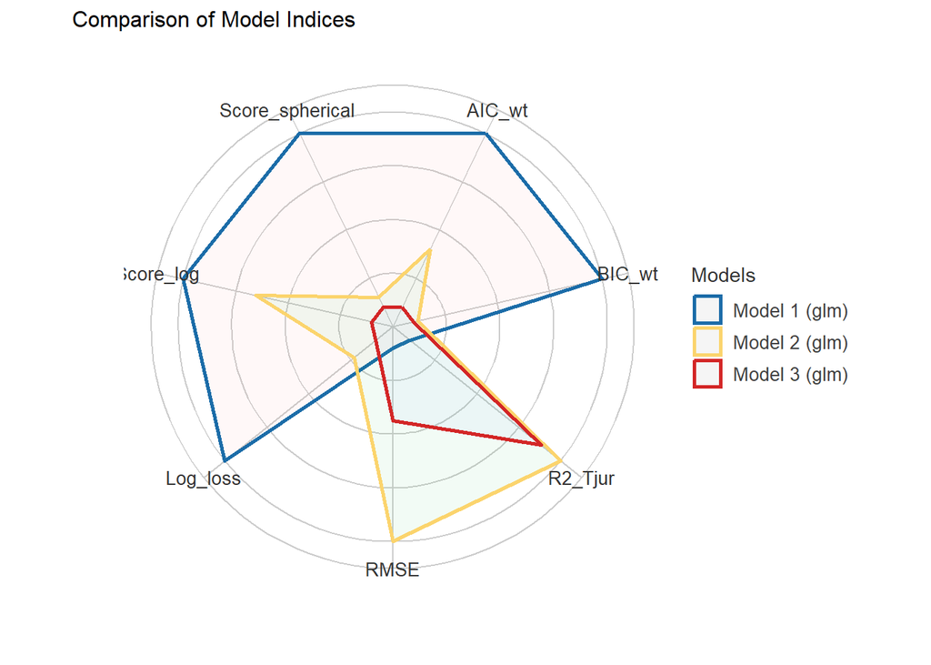

### Estimates

|  | m1 |  |  |  | m2 |  |  |  | m3 |  |  |  |
| --- | --- | --- | --- | --- | --- | --- | --- | --- | --- | --- | --- | --- |
| Predictors | Odds Ratios | std. Error | Statistic | p | Odds Ratios | std. Error | Statistic | p | Odds Ratios | std. Error | Statistic | p |
| (Intercept) | 0.02 (0.01 – 0.02) | 0.00 | -24.19 | **<0.001** | 0.02 (0.01 – 0.02) | 0.00 | -24.13 | **<0.001** | 0.02 (0.01 – 0.02) | 0.00 | -24.07 | **<0.001** |
| intRS y2 | 2.96 (1.85 – 4.66) | 0.70 | 4.62 | **<0.001** | 3.03 (1.88 – 4.79) | 0.72 | 4.66 | **<0.001** | 3.05 (1.89 – 4.83) | 0.73 | 4.67 | **<0.001** |
| PRS |  |  |  |  | 0.91 (0.67 – 1.23) | 0.14 | -0.63 | 0.528 | 0.93 (0.66 – 1.30) | 0.16 | -0.44 | 0.661 |
| intRS y2 × PRS |  |  |  |  |  |  |  |  | 0.94 (0.59 – 1.49) | 0.22 | -0.26 | 0.796 |
| Observations | 2440 |  |  |  | 2440 |  |  |  | 2440 |  |  |  |
| R<sup>2</sup> Tjur | 0.011 |  |  |  | 0.011 |  |  |  | 0.011 |  |  |  |

| model | Accuracy | SE | CI | CI_low | CI_high | Method |
| --- | --- | --- | --- | --- | --- | --- |
| 1 | 0.651 | 0.079 | 0.95 | 0.564 | 0.745 | Area under Curve |
| 2 | 0.654 | 0.131 | 0.95 | 0.486 | 0.814 | Area under Curve |
| 3 | 0.615 | 0.186 | 0.95 | 0.341 | 0.779 | Area under Curve |

## envRS combined

### Performance metrics

| Name | Model | AIC (weights) | AICc (weights) | BIC (weights) | Tjur’s R2 | RMSE | Sigma | Log_loss | Score_log | Score_spherical | PCP |
| --- | --- | --- | --- | --- | --- | --- | --- | --- | --- | --- | --- |
| depRS | glm | 1312.1 (0.280) | 1312.1 (0.280) | 1325.4 (0.916) | 0.008 | 0.156 | 1.000 | 0.114 | -3.645 | 0.010 | 0.951 |
| intRS | glm | 1319.6 (0.007) | 1319.6 (0.007) | 1332.9 (0.022) | 0.006 | 0.156 | 1.000 | 0.115 | -3.642 | 0.010 | 0.951 |
| combRS | glm | 1310.9 (0.518) | 1310.9 (0.518) | 1330.9 (0.061) | 0.009 | 0.156 | 1.000 | 0.114 | -3.646 | 0.009 | 0.951 |
| interact | glm | 1312.9 (0.195) | 1312.9 (0.195) | 1339.5 (<.001) | 0.009 | 0.156 | 1.000 | 0.114 | -3.646 | 0.009 | 0.951 |

### Model comparisons

| Name | Model | BF | df | df_diff | Chi2 | p |
| --- | --- | --- | --- | --- | --- | --- |
| depRS | glm |  | 2 |  |  |  |
| combRS | glm | 0.067 | 3 | 1.000 | 3.233 | 0.072 |
| interact | glm | 0.014 | 4 | 1.000 | 0.048 | 0.826 |

Models were detected as nested (in terms of fixed parameters) and are compared in sequential order.

| Name | Model | BF | df | df_diff | Chi2 | p |
| --- | --- | --- | --- | --- | --- | --- |
| intRS | glm |  | 2 |  |  |  |
| combRS | glm | 2.76 | 3 | 1.000 | 10.687 | 0.001 |
| interact | glm | 0.014 | 4 | 1.000 | 0.048 | 0.826 |

Models were detected as nested (in terms of fixed parameters) and are compared in sequential order.

### Plot

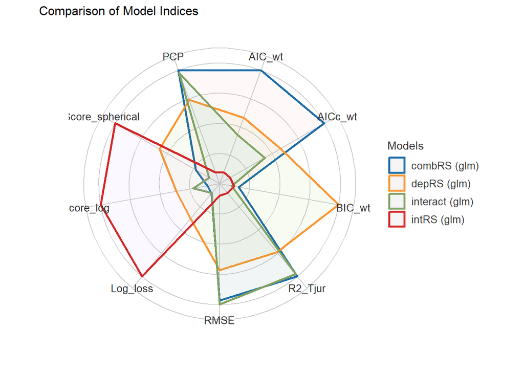

### Estimates

|  | depRS |  |  |  | intRS |  |  |  | depRS+intRS |  |  |  | depRS*intRS |  |  |  |
| --- | --- | --- | --- | --- | --- | --- | --- | --- | --- | --- | --- | --- | --- | --- | --- | --- |
| Predictors | Odds Ratios | std. Error | Statistic | p | Odds Ratios | std. Error | Statistic | p | Odds Ratios | std. Error | Statistic | p | Odds Ratios | std. Error | Statistic | p |
| (Intercept) | 0.02 (0.02 – 0.03) | 0.00 | -40.90 | **<0.001** | 0.02 (0.02 – 0.03) | 0.00 | -41.40 | **<0.001** | 0.02 (0.02 – 0.03) | 0.00 | -40.61 | **<0.001** | 0.02 (0.02 – 0.03) | 0.00 | -38.41 | **<0.001** |
| depRS y2 | 2.33 (1.79 – 3.01) | 0.31 | 6.42 | **<0.001** |  |  |  |  | 6.15 (2.07 – 18.25) | 3.41 | 3.27 | **0.001** | 6.14 (2.07 – 18.24) | 3.41 | 3.27 | **0.001** |
| intRS y2 |  |  |  |  | 2.17 (1.66 – 2.81) | 0.29 | 5.79 | **<0.001** | 0.36 (0.12 – 1.10) | 0.21 | -1.79 | 0.074 | 0.37 (0.11 – 1.20) | 0.22 | -1.65 | 0.099 |
| depRS y2 × intRS y2 |  |  |  |  |  |  |  |  |  |  |  |  | 0.97 (0.69 – 1.30) | 0.16 | -0.22 | 0.827 |
| Observations | 5730 |  |  |  | 5730 |  |  |  | 5730 |  |  |  | 5730 |  |  |  |
| R<sup>2</sup> Tjur | 0.008 |  |  |  | 0.006 |  |  |  | 0.009 |  |  |  | 0.009 |  |  |  |

| model | Accuracy | SE | CI | CI_low | CI_high | Method |
| --- | --- | --- | --- | --- | --- | --- |
| depRS | 0.640 | 0.043 | 0.95 | 0.587 | 0.684 | Area under Curve |
| intRS | 0.630 | 0.075 | 0.95 | 0.547 | 0.726 | Area under Curve |
| combRS | 0.641 | 0.028 | 0.95 | 0.614 | 0.680 | Area under Curve |
| interact | 0.642 | 0.042 | 0.95 | 0.597 | 0.689 | Area under Curve |

# Y2 (longitudinal)

For envRS-only analyses, there are 178 lifetime MDD cases, 26 current MDD cases and 309 cases with lifetime diagnoses of a depressive disorder (Major Depressive Disorder, Persistent Depressive Disorder (dysthymia), Depressive Disorder Unspecified).  
Of those with both envRS and PRS at Y2 (N = 2439), there are 60 lifetime MDD cases, 6 current MDD cases and 113 cases with lifetime diagnoses of a depressive disorder (Major Depressive Disorder, Persistent Depressive Disorder (dysthymia), Depressive Disorder Unspecified).  
*Current analyses use just the lifetime MDD outcome*

## depRS + PRS

### Performance metrics

| Name | Model | AIC (weights) | BIC (weights) | Tjur’s R2 | RMSE | Sigma | Log_loss | Score_log | Score_spherical | AICc (weights) | PCP |
| --- | --- | --- | --- | --- | --- | --- | --- | --- | --- | --- | --- |
| Model 1 | glm | 515.8 (0.150) | 527.4 (0.906) | 0.036 | 0.152 | 1.000 | 0.105 | -1.506 | 0.018 | 515.8 (>.999) | 0.954 |
| Model 2 | glm | 514.8 (0.248) | 532.2 (0.083) | 0.036 | 0.152 | 1.000 | 0.104 | -1.507 | 0.017 | (>.999) |  |
| Model 3 | glm | 513.0 (0.601) | 536.2 (0.011) | 0.037 | 0.152 | 1.000 | 0.104 | -1.508 | 0.017 | (>.999) |  |

### Model comparisons

| Name | Model | BF |
| --- | --- | --- |
| Model 1 | glm |  |
| Model 2 | glm | 0.091 |
| Model 3 | glm | 0.133 |

Models were detected as nested (in terms of fixed parameters) and are compared in sequential order.

### Plot

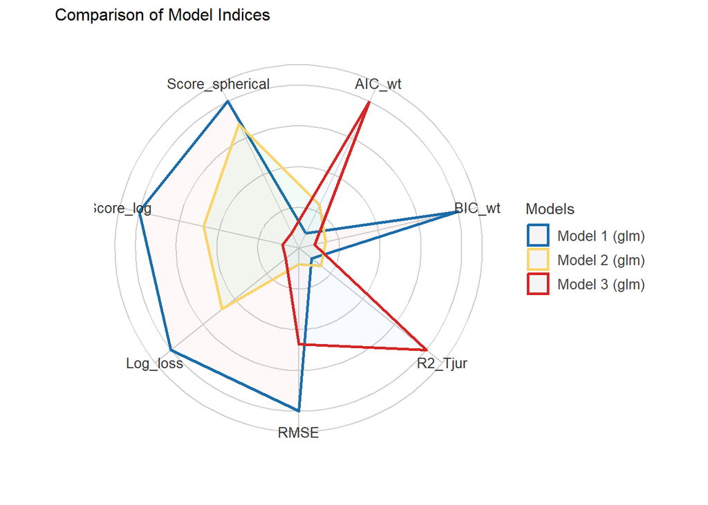

### Estimates

|  | m1 |  |  |  | m2 |  |  |  | m3 |  |  |  |
| --- | --- | --- | --- | --- | --- | --- | --- | --- | --- | --- | --- | --- |
| Predictors | Odds Ratios | std. Error | Statistic | p | Odds Ratios | std. Error | Statistic | p | Odds Ratios | std. Error | Statistic | p |
| (Intercept) | 0.02 (0.01 – 0.02) | 0.00 | -24.61 | **<0.001** | 0.02 (0.01 – 0.02) | 0.00 | -24.28 | **<0.001** | 0.02 (0.01 – 0.02) | 0.00 | -23.12 | **<0.001** |
| depRS y2 | 4.34 (2.96 – 6.37) | 0.85 | 7.53 | **<0.001** | 4.15 (2.82 – 6.11) | 0.82 | 7.22 | **<0.001** | 4.72 (3.14 – 7.14) | 0.99 | 7.43 | **<0.001** |
| PRS |  |  |  |  | 1.27 (0.97 – 1.66) | 0.17 | 1.73 | 0.084 | 1.51 (1.10 – 2.09) | 0.25 | 2.52 | **0.012** |
| depRS y2 × PRS |  |  |  |  |  |  |  |  | 0.68 (0.46 – 1.00) | 0.13 | -1.94 | 0.052 |
| Observations | 2439 |  |  |  | 2439 |  |  |  | 2439 |  |  |  |
| R<sup>2</sup> Tjur | 0.036 |  |  |  | 0.036 |  |  |  | 0.037 |  |  |  |

| model | Accuracy | SE | CI | CI_low | CI_high | Method |
| --- | --- | --- | --- | --- | --- | --- |
| 1 | 0.737 | 0.083 | 0.95 | 0.637 | 0.843 | Area under Curve |
| 2 | 0.743 | 0.041 | 0.95 | 0.683 | 0.780 | Area under Curve |
| 3 | 0.758 | 0.145 | 0.95 | 0.550 | 0.905 | Area under Curve |

## intRS + PRS

### Performance metrics

| Name | Model | AIC (weights) | BIC (weights) | Tjur’s R2 | RMSE | Sigma | Log_loss | Score_log | Score_spherical | AICc (weights) | PCP |
| --- | --- | --- | --- | --- | --- | --- | --- | --- | --- | --- | --- |
| Model 1 | glm | 525.6 (0.174) | 537.2 (0.892) | 0.026 | 0.153 | 1.000 | 0.107 | -1.499 | 0.018 | 525.6 (>.999) | 0.953 |
| Model 2 | glm | 524.2 (0.358) | 541.6 (0.101) | 0.027 | 0.153 | 1.000 | 0.106 | -1.500 | 0.018 | (>.999) |  |
| Model 3 | glm | 523.6 (0.469) | 546.8 (0.007) | 0.028 | 0.153 | 1.000 | 0.106 | -1.500 | 0.017 | (>.999) |  |

### Model comparisons

| Name | Model | BF |
| --- | --- | --- |
| Model 1 | glm |  |
| Model 2 | glm | 0.113 |
| Model 3 | glm | 0.072 |

Models were detected as nested (in terms of fixed parameters) and are compared in sequential order.

### Plot

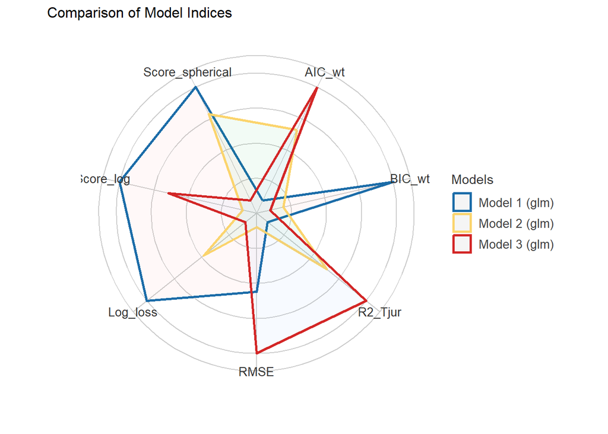

### Estimates

|  | m1 |  |  |  | m2 |  |  |  | m3 |  |  |  |
| --- | --- | --- | --- | --- | --- | --- | --- | --- | --- | --- | --- | --- |
| Predictors | Odds Ratios | std. Error | Statistic | p | Odds Ratios | std. Error | Statistic | p | Odds Ratios | std. Error | Statistic | p |
| (Intercept) | 0.02 (0.01 – 0.03) | 0.00 | -24.99 | **<0.001** | 0.02 (0.01 – 0.02) | 0.00 | -24.65 | **<0.001** | 0.02 (0.01 – 0.02) | 0.00 | -23.65 | **<0.001** |
| intRS y2 | 3.97 (2.66 – 5.89) | 0.80 | 6.83 | **<0.001** | 3.78 (2.52 – 5.62) | 0.77 | 6.52 | **<0.001** | 4.26 (2.78 – 6.53) | 0.92 | 6.69 | **<0.001** |
| PRS |  |  |  |  | 1.29 (0.99 – 1.68) | 0.17 | 1.85 | 0.065 | 1.47 (1.08 – 2.02) | 0.24 | 2.42 | **0.016** |
| intRS y2 × PRS |  |  |  |  |  |  |  |  | 0.72 (0.48 – 1.08) | 0.15 | -1.60 | 0.109 |
| Observations | 2439 |  |  |  | 2439 |  |  |  | 2439 |  |  |  |
| R<sup>2</sup> Tjur | 0.026 |  |  |  | 0.027 |  |  |  | 0.028 |  |  |  |

| model | Accuracy | SE | CI | CI_low | CI_high | Method |
| --- | --- | --- | --- | --- | --- | --- |
| 1 | 0.717 | 0.059 | 0.95 | 0.671 | 0.804 | Area under Curve |
| 2 | 0.734 | 0.083 | 0.95 | 0.631 | 0.826 | Area under Curve |
| 3 | 0.719 | 0.060 | 0.95 | 0.654 | 0.801 | Area under Curve |

## envRS combined

### Performance metrics

| Name | Model | AIC (weights) | AICc (weights) | BIC (weights) | Tjur’s R2 | RMSE | Sigma | Log_loss | Score_log | Score_spherical | PCP |
| --- | --- | --- | --- | --- | --- | --- | --- | --- | --- | --- | --- |
| depRS | glm | 1484.6 (<.001) | 1484.6 (<.001) | 1497.9 (0.018) | 0.024 | 0.172 | 1.000 | 0.129 | -5.642 | 0.008 | 0.941 |
| intRS | glm | 1510.1 (<.001) | 1510.1 (<.001) | 1523.4 (<.001) | 0.017 | 0.172 | 1.000 | 0.131 | -5.620 | 0.008 | 0.941 |
| combRS | glm | 1470.4 (0.121) | 1470.4 (0.121) | 1490.4 (0.779) | 0.030 | 0.171 | 1.000 | 0.128 | -5.660 | 0.008 | 0.942 |
| interact | glm | 1466.4 (0.879) | 1466.5 (0.879) | 1493.1 (0.203) | 0.029 | 0.171 | 1.000 | 0.127 | -5.640 | 0.007 | 0.942 |

### Model comparisons

| Name | Model | BF | df | df_diff | Chi2 | p |
| --- | --- | --- | --- | --- | --- | --- |
| depRS | glm |  | 2 |  |  |  |
| combRS | glm | 43.60 | 3 | 1.000 | 16.204 | < .001 |
| interact | glm | 0.261 | 4 | 1.000 | 5.967 | 0.015 |

Models were detected as nested (in terms of fixed parameters) and are compared in sequential order.

| Name | Model | BF | df | df_diff | Chi2 | p |
| --- | --- | --- | --- | --- | --- | --- |
| intRS | glm |  | 2 |  |  |  |
| combRS | glm | > 1000 | 3 | 1.000 | 41.644 | < .001 |
| interact | glm | 0.261 | 4 | 1.000 | 5.967 | 0.015 |

Models were detected as nested (in terms of fixed parameters) and are compared in sequential order.

### Plot

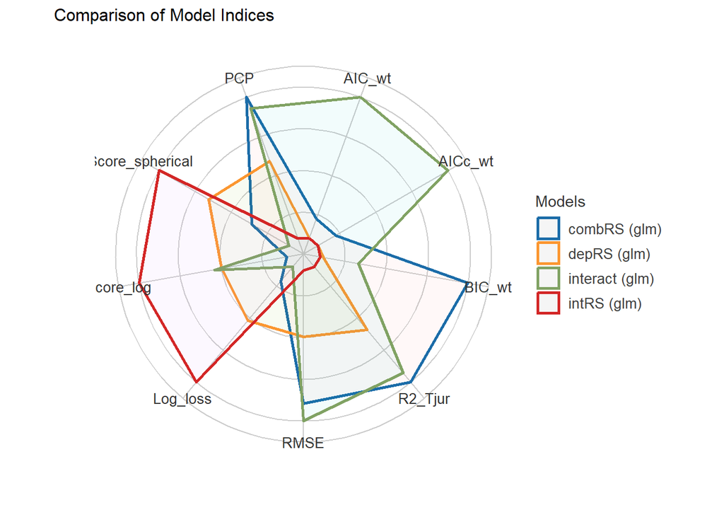

### Estimates

|  | depRS |  |  |  | intRS |  |  |  | depRS+intRS |  |  |  | depRS*intRS |  |  |  |
| --- | --- | --- | --- | --- | --- | --- | --- | --- | --- | --- | --- | --- | --- | --- | --- | --- |
| Predictors | Odds Ratios | std. Error | Statistic | p | Odds Ratios | std. Error | Statistic | p | Odds Ratios | std. Error | Statistic | p | Odds Ratios | std. Error | Statistic | p |
| (Intercept) | 0.03 (0.02 – 0.03) | 0.00 | -40.76 | **<0.001** | 0.03 (0.02 – 0.03) | 0.00 | -41.78 | **<0.001** | 0.02 (0.02 – 0.03) | 0.00 | -39.93 | **<0.001** | 0.02 (0.02 – 0.03) | 0.00 | -38.09 | **<0.001** |
| depRS y2 | 3.49 (2.78 – 4.38) | 0.40 | 10.78 | **<0.001** |  |  |  |  | 24.36 (9.16 – 65.85) | 12.25 | 6.35 | **<0.001** | 25.00 (9.40 – 67.38) | 12.55 | 6.41 | **<0.001** |
| intRS y2 |  |  |  |  | 3.02 (2.40 – 3.79) | 0.35 | 9.55 | **<0.001** | 0.13 (0.05 – 0.36) | 0.07 | -3.94 | **<0.001** | 0.20 (0.07 – 0.57) | 0.11 | -2.97 | **0.003** |
| depRS y2 × intRS y2 |  |  |  |  |  |  |  |  |  |  |  |  | 0.68 (0.48 – 0.93) | 0.11 | -2.29 | **0.022** |
| Observations | 5732 |  |  |  | 5732 |  |  |  | 5732 |  |  |  | 5732 |  |  |  |
| R<sup>2</sup> Tjur | 0.024 |  |  |  | 0.017 |  |  |  | 0.030 |  |  |  | 0.029 |  |  |  |

| model | Accuracy | SE | CI | CI_low | CI_high | Method |
| --- | --- | --- | --- | --- | --- | --- |
| depRS | 0.721 | 0.025 | 0.95 | 0.694 | 0.744 | Area under Curve |
| intRS | 0.705 | 0.023 | 0.95 | 0.684 | 0.739 | Area under Curve |
| combRS | 0.722 | 0.036 | 0.95 | 0.680 | 0.769 | Area under Curve |
| interact | 0.728 | 0.038 | 0.95 | 0.672 | 0.765 | Area under Curve |

# Lifetime MDD diagnosis (parent)

Depression diagnoses (lifetime and current) from *parent-reported* KSADS are available at year 2 (N=5695) and year 2 (N=5758).

# Year 2 (cross-sectional)

## depRS + PRS

### Performance metrics

| Name | Model | AIC (weights) | BIC (weights) | Tjur’s R2 | RMSE | Sigma | Log_loss | Score_log | Score_spherical | AICc (weights) | PCP |
| --- | --- | --- | --- | --- | --- | --- | --- | --- | --- | --- | --- |
| Model 1 | glm | 432.9 (0.610) | 444.5 (0.975) | 0.011 | 0.134 | 1.000 | 0.088 | -0.842 | 0.019 | 432.9 (>.999) | 0.964 |
| Model 2 | glm | 434.4 (0.283) | 451.8 (0.025) | 0.012 | 0.134 | 1.000 | 0.088 | -0.842 | 0.019 | (>.999) |  |
| Model 3 | glm | 436.4 (0.108) | 459.6 (<.001) | 0.011 | 0.134 | 1.000 | 0.088 | -0.842 | 0.019 | (>.999) |  |

### Model comparisons

| Name | Model | BF |
| --- | --- | --- |
| Model 1 | glm |  |
| Model 2 | glm | 0.026 |
| Model 3 | glm | 0.021 |

Models were detected as nested (in terms of fixed parameters) and are compared in sequential order.

### Plot

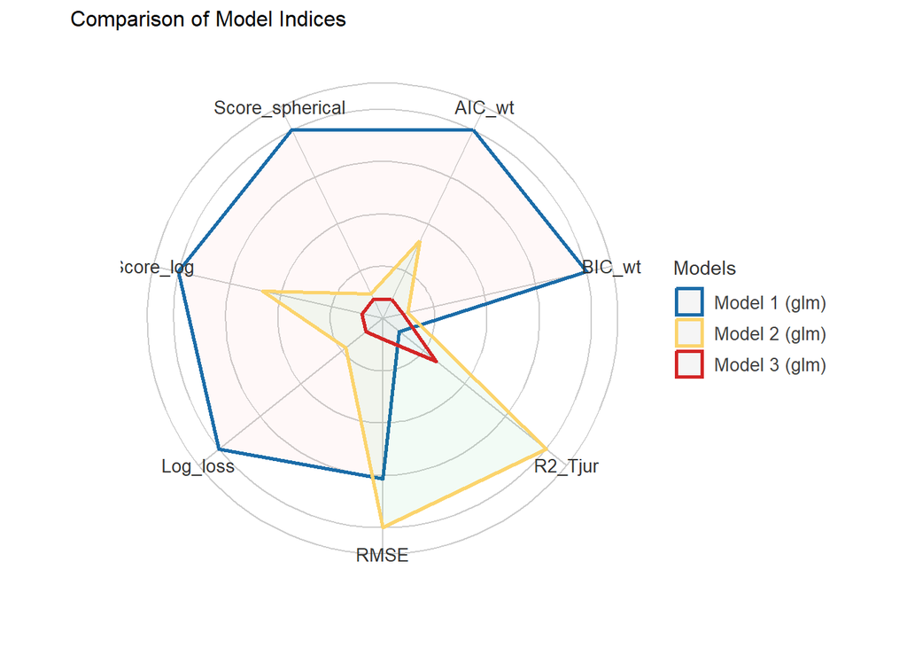

### Estimates

|  | m1 |  |  |  | m2 |  |  |  | m3 |  |  |  |
| --- | --- | --- | --- | --- | --- | --- | --- | --- | --- | --- | --- | --- |
| Predictors | Odds Ratios | std. Error | Statistic | p | Odds Ratios | std. Error | Statistic | p | Odds Ratios | std. Error | Statistic | p |
| (Intercept) | 0.02 (0.01 – 0.02) | 0.00 | -24.21 | **<0.001** | 0.02 (0.01 – 0.02) | 0.00 | -24.16 | **<0.001** | 0.02 (0.01 – 0.02) | 0.00 | -24.08 | **<0.001** |
| depRS y2 | 2.91 (1.85 – 4.48) | 0.66 | 4.73 | **<0.001** | 2.97 (1.88 – 4.61) | 0.68 | 4.78 | **<0.001** | 2.99 (1.89 – 4.64) | 0.68 | 4.79 | **<0.001** |
| PRS |  |  |  |  | 0.90 (0.67 – 1.22) | 0.14 | -0.68 | 0.497 | 0.92 (0.66 – 1.29) | 0.16 | -0.48 | 0.630 |
| depRS y2 × PRS |  |  |  |  |  |  |  |  | 0.94 (0.60 – 1.46) | 0.21 | -0.27 | 0.786 |
| Observations | 2440 |  |  |  | 2440 |  |  |  | 2440 |  |  |  |
| R<sup>2</sup> Tjur | 0.011 |  |  |  | 0.012 |  |  |  | 0.011 |  |  |  |

| model | Accuracy | SE | CI | CI_low | CI_high | Method |
| --- | --- | --- | --- | --- | --- | --- |
| 1 | 0.691 | 0.064 | 0.95 | 0.599 | 0.750 | Area under Curve |
| 2 | 0.670 | 0.029 | 0.95 | 0.635 | 0.709 | Area under Curve |
| 3 | 0.641 | 0.079 | 0.95 | 0.536 | 0.727 | Area under Curve |

## intRS + PRS

### Performance metrics

| Name | Model | AIC (weights) | BIC (weights) | Tjur’s R2 | RMSE | Sigma | Log_loss | Score_log | Score_spherical | AICc (weights) | PCP |
| --- | --- | --- | --- | --- | --- | --- | --- | --- | --- | --- | --- |
| Model 1 | glm | 433.9 (0.617) | 445.5 (0.975) | 0.011 | 0.134 | 1.000 | 0.088 | -0.842 | 0.019 | 433.9 (>.999) | 0.964 |
| Model 2 | glm | 435.5 (0.277) | 452.9 (0.024) | 0.011 | 0.134 | 1.000 | 0.088 | -0.842 | 0.019 | (>.999) |  |
| Model 3 | glm | 437.4 (0.105) | 460.6 (<.001) | 0.011 | 0.134 | 1.000 | 0.088 | -0.842 | 0.019 | (>.999) |  |

### Model comparisons

| Name | Model | BF |
| --- | --- | --- |
| Model 1 | glm |  |
| Model 2 | glm | 0.025 |
| Model 3 | glm | 0.021 |

Models were detected as nested (in terms of fixed parameters) and are compared in sequential order.

### Plot

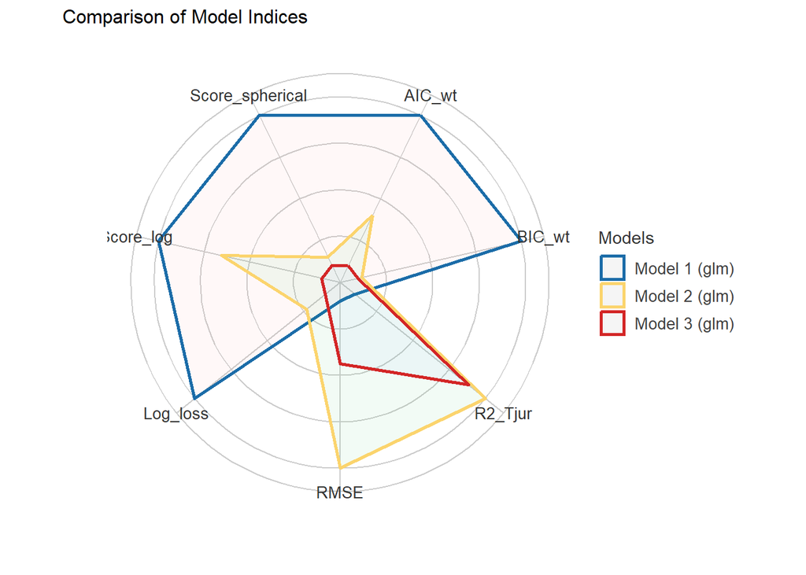

### Estimates

|  | m1 |  |  |  | m2 |  |  |  | m3 |  |  |  |
| --- | --- | --- | --- | --- | --- | --- | --- | --- | --- | --- | --- | --- |
| Predictors | Odds Ratios | std. Error | Statistic | p | Odds Ratios | std. Error | Statistic | p | Odds Ratios | std. Error | Statistic | p |
| (Intercept) | 0.02 (0.01 – 0.02) | 0.00 | -24.19 | **<0.001** | 0.02 (0.01 – 0.02) | 0.00 | -24.13 | **<0.001** | 0.02 (0.01 – 0.02) | 0.00 | -24.07 | **<0.001** |
| intRS y2 | 2.96 (1.85 – 4.66) | 0.70 | 4.62 | **<0.001** | 3.03 (1.88 – 4.79) | 0.72 | 4.66 | **<0.001** | 3.05 (1.89 – 4.83) | 0.73 | 4.67 | **<0.001** |
| PRS |  |  |  |  | 0.91 (0.67 – 1.23) | 0.14 | -0.63 | 0.528 | 0.93 (0.66 – 1.30) | 0.16 | -0.44 | 0.661 |
| intRS y2 × PRS |  |  |  |  |  |  |  |  | 0.94 (0.59 – 1.49) | 0.22 | -0.26 | 0.796 |
| Observations | 2440 |  |  |  | 2440 |  |  |  | 2440 |  |  |  |
| R<sup>2</sup> Tjur | 0.011 |  |  |  | 0.011 |  |  |  | 0.011 |  |  |  |

| model | Accuracy | SE | CI | CI_low | CI_high | Method |
| --- | --- | --- | --- | --- | --- | --- |
| 1 | 0.648 | 0.107 | 0.95 | 0.509 | 0.746 | Area under Curve |
| 2 | 0.656 | 0.066 | 0.95 | 0.594 | 0.739 | Area under Curve |
| 3 | 0.599 | 0.128 | 0.95 | 0.444 | 0.756 | Area under Curve |

## envRS combined

### Performance metrics

| Name | Model | AIC (weights) | AICc (weights) | BIC (weights) | Tjur’s R2 | RMSE | Sigma | Log_loss | Score_log | Score_spherical | PCP |
| --- | --- | --- | --- | --- | --- | --- | --- | --- | --- | --- | --- |
| depRS | glm | 1101.6 (0.607) | 1101.6 (0.607) | 1114.9 (0.933) | 0.032 | 0.144 | 1.000 | 0.096 | -2.794 | 0.010 | 0.958 |
| intRS | glm | 1107.2 (0.036) | 1107.2 (0.036) | 1120.5 (0.055) | 0.031 | 0.144 | 1.000 | 0.097 | -2.795 | 0.010 | 0.958 |
| combRS | glm | 1103.5 (0.226) | 1103.5 (0.226) | 1123.5 (0.013) | 0.032 | 0.144 | 1.000 | 0.096 | -2.794 | 0.010 | 0.958 |
| interact | glm | 1104.6 (0.131) | 1104.6 (0.131) | 1131.2 (<.001) | 0.029 | 0.144 | 1.000 | 0.096 | -2.786 | 0.010 | 0.958 |

### Model comparisons

| Name | Model | BF | df | df_diff | Chi2 | p |
| --- | --- | --- | --- | --- | --- | --- |
| depRS | glm |  | 2 |  |  |  |
| combRS | glm | 0.013 | 3 | 1.000 | 0.029 | 0.864 |
| interact | glm | 0.021 | 4 | 1.000 | 0.913 | 0.339 |

Models were detected as nested (in terms of fixed parameters) and are compared in sequential order.

| Name | Model | BF | df | df_diff | Chi2 | p |
| --- | --- | --- | --- | --- | --- | --- |
| intRS | glm |  | 2 |  |  |  |
| combRS | glm | 0.230 | 3 | 1.000 | 5.704 | 0.017 |
| interact | glm | 0.021 | 4 | 1.000 | 0.913 | 0.339 |

Models were detected as nested (in terms of fixed parameters) and are compared in sequential order.

### Plot

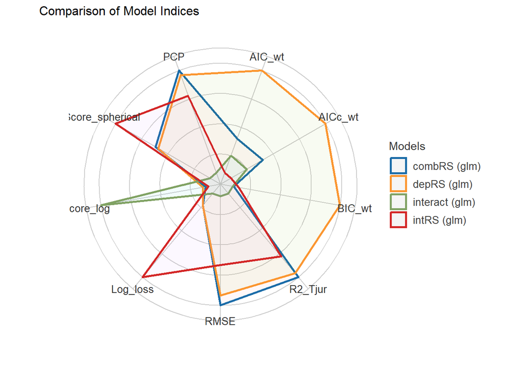

### Estimates

|  | depRS |  |  |  | intRS |  |  |  | depRS+intRS |  |  |  | depRS*intRS |  |  |  |
| --- | --- | --- | --- | --- | --- | --- | --- | --- | --- | --- | --- | --- | --- | --- | --- | --- |
| Predictors | Odds Ratios | std. Error | Statistic | p | Odds Ratios | std. Error | Statistic | p | Odds Ratios | std. Error | Statistic | p | Odds Ratios | std. Error | Statistic | p |
| (Intercept) | 0.02 (0.01 – 0.02) | 0.00 | -36.55 | **<0.001** | 0.02 (0.01 – 0.02) | 0.00 | -37.09 | **<0.001** | 0.02 (0.01 – 0.02) | 0.00 | -36.53 | **<0.001** | 0.02 (0.01 – 0.02) | 0.00 | -35.86 | **<0.001** |
| depRS y2 | 4.16 (3.20 – 5.39) | 0.55 | 10.76 | **<0.001** |  |  |  |  | 3.79 (1.27 – 11.30) | 2.11 | 2.39 | **0.017** | 3.87 (1.30 – 11.56) | 2.16 | 2.43 | **0.015** |
| intRS y2 |  |  |  |  | 3.99 (3.09 – 5.16) | 0.52 | 10.61 | **<0.001** | 1.10 (0.37 – 3.27) | 0.61 | 0.17 | 0.864 | 1.32 (0.41 – 4.17) | 0.78 | 0.47 | 0.635 |
| depRS y2 × intRS y2 |  |  |  |  |  |  |  |  |  |  |  |  | 0.86 (0.62 – 1.16) | 0.14 | -0.94 | 0.347 |
| Observations | 5695 |  |  |  | 5695 |  |  |  | 5695 |  |  |  | 5695 |  |  |  |
| R<sup>2</sup> Tjur | 0.032 |  |  |  | 0.031 |  |  |  | 0.032 |  |  |  | 0.029 |  |  |  |

| model | Accuracy | SE | CI | CI_low | CI_high | Method |
| --- | --- | --- | --- | --- | --- | --- |
| depRS | 0.749 | 0.032 | 0.95 | 0.709 | 0.780 | Area under Curve |
| intRS | 0.742 | 0.033 | 0.95 | 0.716 | 0.794 | Area under Curve |
| combRS | 0.749 | 0.048 | 0.95 | 0.679 | 0.796 | Area under Curve |
| interact | 0.745 | 0.028 | 0.95 | 0.721 | 0.786 | Area under Curve |

# Y2 (longitudinal)

For envRS-only analyses, there are 207 lifetime MDD cases, 19 current MDD cases and 444 cases with lifetime diagnoses of a depressive disorder (Major Depressive Disorder, Persistent Depressive Disorder (dysthymia), Depressive Disorder Unspecified).  
Of those with both envRS and PRS at Y2 (N = 2450), there are 98 lifetime MDD cases, 14 current MDD cases and 201 cases with lifetime diagnoses of a depressive disorder (Major Depressive Disorder, Persistent Depressive Disorder (dysthymia), Depressive Disorder Unspecified).  
Current analyses use *just* the lifetime MDD outcome.

## depRS + PRS

### Performance metrics

| Name | Model | AIC (weights) | BIC (weights) | Tjur’s R2 | RMSE | Sigma | Log_loss | Score_log | Score_spherical | AICc (weights) | PCP |
| --- | --- | --- | --- | --- | --- | --- | --- | --- | --- | --- | --- |
| Model 1 | glm | 712.8 (0.283) | 724.4 (0.914) | 0.080 | 0.189 | 1.000 | 0.145 | -4.145 | 0.014 | 712.8 (>.999) | 0.929 |
| Model 2 | glm | 711.8 (0.470) | 729.2 (0.083) | 0.082 | 0.188 | 1.000 | 0.144 | -4.150 | 0.014 | (>.999) |  |
| Model 3 | glm | 713.1 (0.246) | 736.3 (0.002) | 0.081 | 0.188 | 1.000 | 0.144 | -4.143 | 0.014 | (>.999) |  |

### Model comparisons

| Name | Model | BF |
| --- | --- | --- |
| Model 1 | glm |  |
| Model 2 | glm | 0.091 |
| Model 3 | glm | 0.029 |

Models were detected as nested (in terms of fixed parameters) and are compared in sequential order.

### Plot

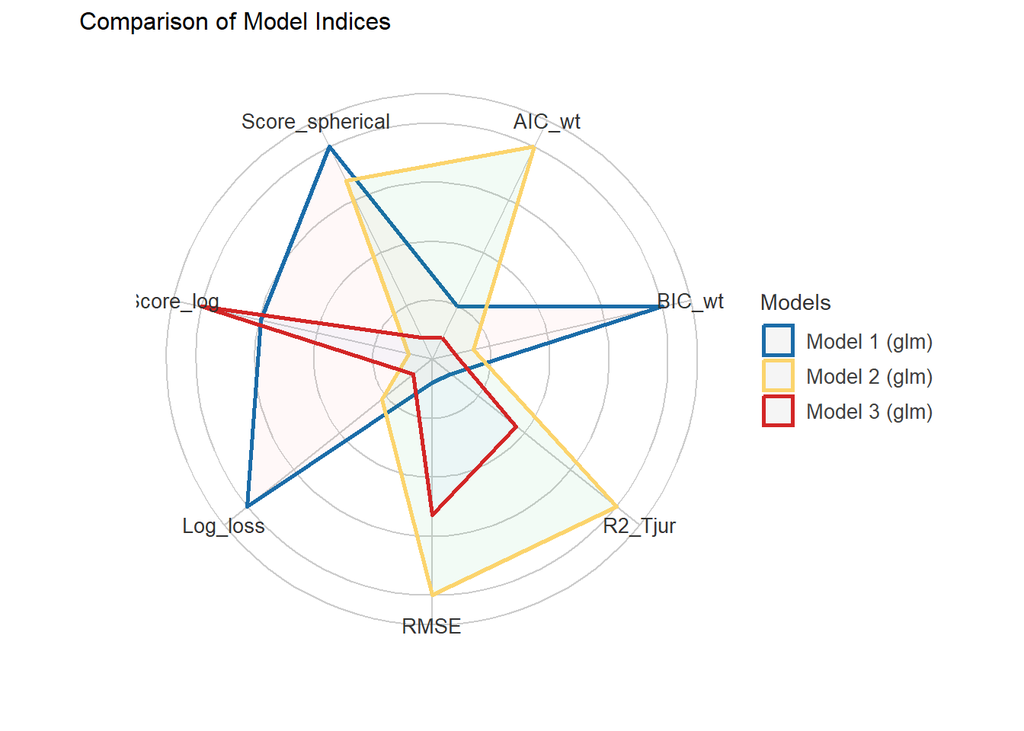

### Estimates

|  | m1 |  |  |  | m2 |  |  |  | m3 |  |  |  |
| --- | --- | --- | --- | --- | --- | --- | --- | --- | --- | --- | --- | --- |
| Predictors | Odds Ratios | std. Error | Statistic | p | Odds Ratios | std. Error | Statistic | p | Odds Ratios | std. Error | Statistic | p |
| (Intercept) | 0.03 (0.02 – 0.03) | 0.00 | -26.45 | **<0.001** | 0.03 (0.02 – 0.03) | 0.00 | -26.25 | **<0.001** | 0.03 (0.02 – 0.03) | 0.00 | -25.80 | **<0.001** |
| depRS y2 | 5.73 (4.17 – 7.93) | 0.94 | 10.68 | **<0.001** | 5.53 (4.02 – 7.67) | 0.91 | 10.39 | **<0.001** | 5.77 (4.13 – 8.15) | 1.00 | 10.15 | **<0.001** |
| PRS |  |  |  |  | 1.21 (0.98 – 1.51) | 0.13 | 1.73 | 0.084 | 1.30 (0.99 – 1.70) | 0.18 | 1.89 | 0.059 |
| depRS y2 × PRS |  |  |  |  |  |  |  |  | 0.87 (0.62 – 1.21) | 0.15 | -0.84 | 0.401 |
| Observations | 2450 |  |  |  | 2450 |  |  |  | 2450 |  |  |  |
| R<sup>2</sup> Tjur | 0.080 |  |  |  | 0.082 |  |  |  | 0.081 |  |  |  |

| model | Accuracy | SE | CI | CI_low | CI_high | Method |
| --- | --- | --- | --- | --- | --- | --- |
| 1 | 0.787 | 0.053 | 0.95 | 0.713 | 0.847 | Area under Curve |
| 2 | 0.789 | 0.035 | 0.95 | 0.753 | 0.833 | Area under Curve |
| 3 | 0.798 | 0.048 | 0.95 | 0.742 | 0.853 | Area under Curve |

## intRS + PRS

### Performance metrics

| Name | Model | AIC (weights) | BIC (weights) | Tjur’s R2 | RMSE | Sigma | Log_loss | Score_log | Score_spherical | AICc (weights) | PCP |
| --- | --- | --- | --- | --- | --- | --- | --- | --- | --- | --- | --- |
| Model 1 | glm | 724.6 (0.230) | 736.2 (0.896) | 0.067 | 0.190 | 1.000 | 0.147 | -4.109 | 0.014 | 724.6 (>.999) | 0.928 |
| Model 2 | glm | 723.1 (0.471) | 740.5 (0.101) | 0.069 | 0.190 | 1.000 | 0.146 | -4.116 | 0.014 | (>.999) |  |
| Model 3 | glm | 724.0 (0.299) | 747.2 (0.004) | 0.068 | 0.190 | 1.000 | 0.146 | -4.108 | 0.014 | (>.999) |  |

### Model comparisons

| Name | Model | BF |
| --- | --- | --- |
| Model 1 | glm |  |
| Model 2 | glm | 0.112 |
| Model 3 | glm | 0.035 |

Models were detected as nested (in terms of fixed parameters) and are compared in sequential order.

### Plot

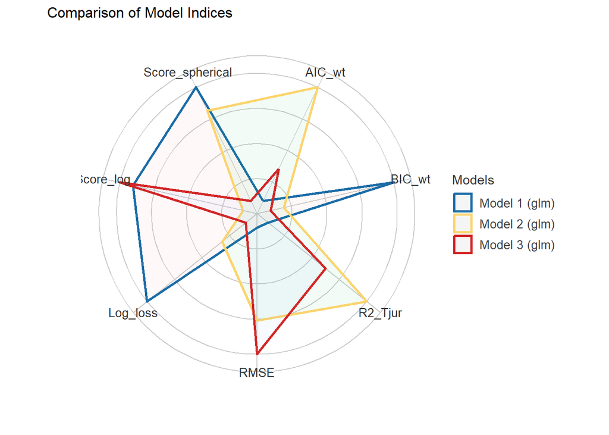

### Estimates

|  | m1 |  |  |  | m2 |  |  |  | m3 |  |  |  |
| --- | --- | --- | --- | --- | --- | --- | --- | --- | --- | --- | --- | --- |
| Predictors | Odds Ratios | std. Error | Statistic | p | Odds Ratios | std. Error | Statistic | p | Odds Ratios | std. Error | Statistic | p |
| (Intercept) | 0.03 (0.02 – 0.04) | 0.00 | -26.68 | **<0.001** | 0.03 (0.02 – 0.03) | 0.00 | -26.50 | **<0.001** | 0.03 (0.02 – 0.03) | 0.00 | -25.89 | **<0.001** |
| intRS y2 | 5.57 (4.02 – 7.76) | 0.93 | 10.27 | **<0.001** | 5.35 (3.86 – 7.48) | 0.90 | 9.95 | **<0.001** | 5.69 (4.02 – 8.11) | 1.01 | 9.74 | **<0.001** |
| PRS |  |  |  |  | 1.22 (0.99 – 1.52) | 0.13 | 1.84 | 0.065 | 1.33 (1.02 – 1.74) | 0.18 | 2.10 | **0.036** |
| intRS y2 × PRS |  |  |  |  |  |  |  |  | 0.83 (0.59 – 1.17) | 0.14 | -1.05 | 0.296 |
| Observations | 2450 |  |  |  | 2450 |  |  |  | 2450 |  |  |  |
| R<sup>2</sup> Tjur | 0.067 |  |  |  | 0.069 |  |  |  | 0.068 |  |  |  |

| model | Accuracy | SE | CI | CI_low | CI_high | Method |
| --- | --- | --- | --- | --- | --- | --- |
| 1 | 0.776 | 0.043 | 0.95 | 0.735 | 0.835 | Area under Curve |
| 2 | 0.783 | 0.018 | 0.95 | 0.768 | 0.809 | Area under Curve |
| 3 | 0.788 | 0.053 | 0.95 | 0.716 | 0.843 | Area under Curve |

## envRS combined

### Performance metrics

| Name | Model | AIC (weights) | AICc (weights) | BIC (weights) | Tjur’s R2 | RMSE | Sigma | Log_loss | Score_log | Score_spherical | PCP |
| --- | --- | --- | --- | --- | --- | --- | --- | --- | --- | --- | --- |
| depRS | glm | 1553.1 (0.012) | 1553.1 (0.012) | 1566.4 (0.831) | 0.066 | 0.181 | 1.000 | 0.135 | -7.850 | 0.007 | 0.935 |
| intRS | glm | 1582.4 (<.001) | 1582.4 (<.001) | 1595.7 (<.001) | 0.054 | 0.182 | 1.000 | 0.137 | -7.809 | 0.007 | 0.934 |
| combRS | glm | 1551.1 (0.031) | 1551.1 (0.031) | 1571.0 (0.081) | 0.068 | 0.180 | 1.000 | 0.134 | -7.856 | 0.007 | 0.935 |
| interact | glm | 1544.2 (0.957) | 1544.2 (0.957) | 1570.8 (0.089) | 0.063 | 0.180 | 1.000 | 0.133 | -7.759 | 0.007 | 0.935 |

### Model comparisons

| Name | Model | BF | df | df_diff | Chi2 | p |
| --- | --- | --- | --- | --- | --- | --- |
| depRS | glm |  | 2 |  |  |  |
| combRS | glm | 0.097 | 3 | 1.000 | 4.002 | 0.045 |
| interact | glm | 1.09 | 4 | 1.000 | 8.837 | 0.003 |

Models were detected as nested (in terms of fixed parameters) and are compared in sequential order.

| Name | Model | BF | df | df_diff | Chi2 | p |
| --- | --- | --- | --- | --- | --- | --- |
| intRS | glm |  | 2 |  |  |  |
| combRS | glm | > 1000 | 3 | 1.000 | 33.328 | < .001 |
| interact | glm | 1.09 | 4 | 1.000 | 8.837 | 0.003 |

Models were detected as nested (in terms of fixed parameters) and are compared in sequential order.

### Plot

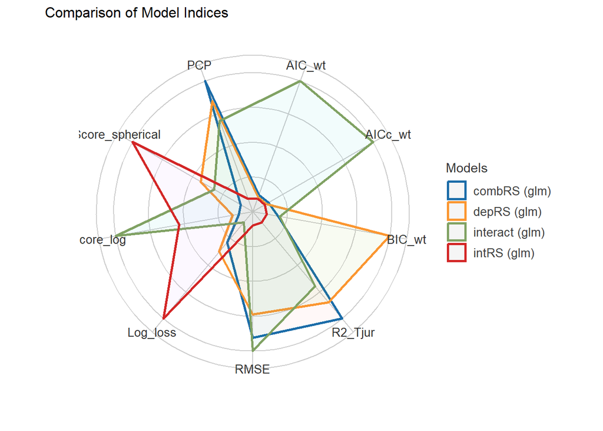

### Estimates

|  | depRS |  |  |  | intRS |  |  |  | depRS+intRS |  |  |  | depRS*intRS |  |  |  |
| --- | --- | --- | --- | --- | --- | --- | --- | --- | --- | --- | --- | --- | --- | --- | --- | --- |
| Predictors | Odds Ratios | std. Error | Statistic | p | Odds Ratios | std. Error | Statistic | p | Odds Ratios | std. Error | Statistic | p | Odds Ratios | std. Error | Statistic | p |
| (Intercept) | 0.02 (0.02 – 0.03) | 0.00 | -39.62 | **<0.001** | 0.03 (0.02 – 0.03) | 0.00 | -40.60 | **<0.001** | 0.02 (0.02 – 0.03) | 0.00 | -39.35 | **<0.001** | 0.02 (0.02 – 0.03) | 0.00 | -37.33 | **<0.001** |
| depRS y2 | 5.49 (4.43 – 6.83) | 0.61 | 15.38 | **<0.001** |  |  |  |  | 13.11 (5.44 – 32.07) | 5.93 | 5.69 | **<0.001** | 14.31 (5.95 – 34.85) | 6.44 | 5.91 | **<0.001** |
| intRS y2 |  |  |  |  | 4.91 (3.98 – 6.09) | 0.53 | 14.67 | **<0.001** | 0.41 (0.17 – 0.98) | 0.18 | -1.98 | **0.047** | 0.67 (0.26 – 1.68) | 0.32 | -0.85 | 0.393 |
| depRS y2 × intRS y2 |  |  |  |  |  |  |  |  |  |  |  |  | 0.66 (0.49 – 0.87) | 0.10 | -2.85 | **0.004** |
| Observations | 5758 |  |  |  | 5758 |  |  |  | 5758 |  |  |  | 5758 |  |  |  |
| R<sup>2</sup> Tjur | 0.066 |  |  |  | 0.054 |  |  |  | 0.068 |  |  |  | 0.063 |  |  |  |

| model | Accuracy | SE | CI | CI_low | CI_high | Method |
| --- | --- | --- | --- | --- | --- | --- |
| depRS | 0.788 | 0.041 | 0.95 | 0.729 | 0.833 | Area under Curve |
| intRS | 0.782 | 0.036 | 0.95 | 0.727 | 0.806 | Area under Curve |
| combRS | 0.790 | 0.046 | 0.95 | 0.725 | 0.839 | Area under Curve |
| interact | 0.788 | 0.046 | 0.95 | 0.728 | 0.847 | Area under Curve |